# GaussianMixture

**class*sklearn.mixture.GaussianMixture(*n_components=1*, *, *covariance_type='full'*, *tol=0.001*, *reg_covar=1e-06*, *max_iter=100*, *n_init=1*, *init_params='kmeans'*, *weights_init=None*, *means_init=None*, *precisions_init=None*, *random_state=None*, *warm_start=False*, *verbose=0*, *verbose_interval=10*)[[source]](https://github.com/scikit-learn/scikit-learn/blob/99bf3d8e4/sklearn/mixture/_gaussian_mixture.py#L509)**

Gaussian Mixture.

Representation of a Gaussian mixture model probability distribution. This class allows to estimate the parameters of a Gaussian mixture distribution.

Read more in the User Guide.

Added in version 0.18.

**Parameters:**

**n_components**int, default=1**

The number of mixture components.

**covariance_type**{‘full’, ‘tied’, ‘diag’, ‘spherical’}, default=’full’**

String describing the type of covariance parameters to use. Must be one of:

- ‘full’: each component has its own general covariance matrix.
- ‘tied’: all components share the same general covariance matrix.
- ‘diag’: each component has its own diagonal covariance matrix.
- ‘spherical’: each component has its own single variance.

**tol**float, default=1e-3**

The convergence threshold. EM iterations will stop when the lower bound average gain is below this threshold.

**reg_covar**float, default=1e-6**

Non-negative regularization added to the diagonal of covariance. Allows to assure that the covariance matrices are all positive.

**max_iter**int, default=100**

The number of EM iterations to perform.

**n_init**int, default=1**

The number of initializations to perform. The best results are kept.

**init_params**{‘kmeans’, ‘k-means++’, ‘random’, ‘random_from_data’}, default=’kmeans’**

The method used to initialize the weights, the means and the precisions. String must be one of:

- ‘kmeans’ : responsibilities are initialized using kmeans.
- ‘k-means++’ : use the k-means++ method to initialize.
- ‘random’ : responsibilities are initialized randomly.
- ‘random_from_data’ : initial means are randomly selected data points.

Changed in version v1.1: `init_params` now accepts ‘random_from_data’ and ‘k-means++’ as initialization methods.

**weights_init**array-like of shape (n_components, ), default=None**

The user-provided initial weights. If it is None, weights are initialized using the `init_params` method.

**means_init**array-like of shape (n_components, n_features), default=None**

The user-provided initial means, If it is None, means are initialized using the `init_params` method.

**precisions_init**array-like, default=None**

The user-provided initial precisions (inverse of the covariance matrices). If it is None, precisions are initialized using the ‘init_params’ method. The shape depends on ‘covariance_type’:

```
(n_components,)                        if 'spherical',
(n_features, n_features)               if 'tied',
(n_components, n_features)             if 'diag',
(n_components, n_features, n_features) if 'full'
```

**random_state**int, RandomState instance or None, default=None**

Controls the random seed given to the method chosen to initialize the parameters (see `init_params`). In addition, it controls the generation of random samples from the fitted distribution (see the method `sample`). Pass an int for reproducible output across multiple function calls. See [Glossary](https://scikit-learn.org/1.6/glossary.html#term-random_state).

**warm_start**bool, default=False**

If ‘warm_start’ is True, the solution of the last fitting is used as initialization for the next call of fit(). This can speed up convergence when fit is called several times on similar problems. In that case, ‘n_init’ is ignored and only a single initialization occurs upon the first call. See [the Glossary](https://scikit-learn.org/1.6/glossary.html#term-warm_start).

**verbose**int, default=0**

Enable verbose output. If 1 then it prints the current initialization and each iteration step. If greater than 1 then it prints also the log probability and the time needed for each step.

**verbose_interval**int, default=10**

Number of iteration done before the next print.

**Attributes:**

**weights_**array-like of shape (n_components,)**

The weights of each mixture components.

**means_**array-like of shape (n_components, n_features)**

The mean of each mixture component.

**covariances_**array-like**

The covariance of each mixture component. The shape depends on `covariance_type`:

```
(n_components,)                        if 'spherical',
(n_features, n_features)               if 'tied',
(n_components, n_features)             if 'diag',
(n_components, n_features, n_features) if 'full'
```

**precisions_**array-like**

The precision matrices for each component in the mixture. A precision matrix is the inverse of a covariance matrix. A covariance matrix is symmetric positive definite so the mixture of Gaussian can be equivalently parameterized by the precision matrices. Storing the precision matrices instead of the covariance matrices makes it more efficient to compute the log-likelihood of new samples at test time. The shape depends on `covariance_type`:

```
(n_components,)                        if 'spherical',
(n_features, n_features)               if 'tied',
(n_components, n_features)             if 'diag',
(n_components, n_features, n_features) if 'full'
```

**precisions_cholesky_**array-like**

The cholesky decomposition of the precision matrices of each mixture component. A precision matrix is the inverse of a covariance matrix. A covariance matrix is symmetric positive definite so the mixture of Gaussian can be equivalently parameterized by the precision matrices. Storing the precision matrices instead of the covariance matrices makes it more efficient to compute the log-likelihood of new samples at test time. The shape depends on `covariance_type`:

```
(n_components,)                        if 'spherical',
(n_features, n_features)               if 'tied',
(n_components, n_features)             if 'diag',
(n_components, n_features, n_features) if 'full'
```

**converged_**bool**

True when convergence of the best fit of EM was reached, False otherwise.

**n_iter_**int**

Number of step used by the best fit of EM to reach the convergence.

**lower_bound_**float**

Lower bound value on the log-likelihood (of the training data with respect to the model) of the best fit of EM.

**n_features_in_**int**

Number of features seen during fit.

Added in version 0.24.

**feature_names_in_**ndarray of shape (`n_features_in_`,)**

Names of features seen during fit. Defined only when `X` has feature names that are all strings.

Added in version 1.0.

See also

**`BayesianGaussianMixture`**

Gaussian mixture model fit with a variational inference.

#### Examples

```
>>> import numpy as np
>>> from sklearn.mixture import GaussianMixture
>>> X = np.array([[1, 2], [1, 4], [1, 0], [10, 2], [10, 4], [10, 0]])
>>> gm = GaussianMixture(n_components=2, random_state=0).fit(X)
>>> gm.means_
array([[10.,  2.],
       [ 1.,  2.]])
>>> gm.predict([[0, 0], [12, 3]])
array([1, 0])
```

**aic(*X*)[[source]](https://github.com/scikit-learn/scikit-learn/blob/99bf3d8e4/sklearn/mixture/_gaussian_mixture.py#L895)**

Akaike information criterion for the current model on the input X.

You can refer to this mathematical section for more details regarding the formulation of the AIC used.

**Parameters:**

**X**array of shape (n_samples, n_dimensions)**

The input samples.

**Returns:**

**aic**float**

The lower the better.

**bic(*X*)[[source]](https://github.com/scikit-learn/scikit-learn/blob/99bf3d8e4/sklearn/mixture/_gaussian_mixture.py#L875)**

Bayesian information criterion for the current model on the input X.

You can refer to this mathematical section for more details regarding the formulation of the BIC used.

**Parameters:**

**X**array of shape (n_samples, n_dimensions)**

The input samples.

**Returns:**

**bic**float**

The lower the better.

**fit(*X*, *y=None*)[[source]](https://github.com/scikit-learn/scikit-learn/blob/99bf3d8e4/sklearn/mixture/_base.py#L153)**

Estimate model parameters with the EM algorithm.

The method fits the model `n_init` times and sets the parameters with which the model has the largest likelihood or lower bound. Within each trial, the method iterates between E-step and M-step for `max_iter` times until the change of likelihood or lower bound is less than `tol`, otherwise, a `ConvergenceWarning` is raised. If `warm_start` is `True`, then `n_init` is ignored and a single initialization is performed upon the first call. Upon consecutive calls, training starts where it left off.

**Parameters:**

**X**array-like of shape (n_samples, n_features)**

List of n_features-dimensional data points. Each row corresponds to a single data point.

**y**Ignored**

Not used, present for API consistency by convention.

**Returns:**

**self**object**

The fitted mixture.

**fit_predict(*X*, *y=None*)[[source]](https://github.com/scikit-learn/scikit-learn/blob/99bf3d8e4/sklearn/mixture/_base.py#L183)**

Estimate model parameters using X and predict the labels for X.

The method fits the model n_init times and sets the parameters with which the model has the largest likelihood or lower bound. Within each trial, the method iterates between E-step and M-step for `max_iter` times until the change of likelihood or lower bound is less than `tol`, otherwise, a `ConvergenceWarning` is raised. After fitting, it predicts the most probable label for the input data points.

Added in version 0.20.

**Parameters:**

**X**array-like of shape (n_samples, n_features)**

List of n_features-dimensional data points. Each row corresponds to a single data point.

**y**Ignored**

Not used, present for API consistency by convention.

**Returns:**

**labels**array, shape (n_samples,)**

Component labels.

**get_metadata_routing()[[source]](https://github.com/scikit-learn/scikit-learn/blob/99bf3d8e4/sklearn/utils/_metadata_requests.py#L1497)**

Get metadata routing of this object.

Please check [User Guide](https://scikit-learn.org/1.6/metadata_routing.html#metadata-routing) on how the routing mechanism works.

**Returns:**

**routing**MetadataRequest**

A `MetadataRequest` encapsulating routing information.

**get_params(*deep=True*)[[source]](https://github.com/scikit-learn/scikit-learn/blob/99bf3d8e4/sklearn/base.py#L231)**

Get parameters for this estimator.

**Parameters:**

**deep**bool, default=True**

If True, will return the parameters for this estimator and contained subobjects that are estimators.

**Returns:**

**params**dict**

Parameter names mapped to their values.

**predict(*X*)[[source]](https://github.com/scikit-learn/scikit-learn/blob/99bf3d8e4/sklearn/mixture/_base.py#L368)**

Predict the labels for the data samples in X using trained model.

**Parameters:**

**X**array-like of shape (n_samples, n_features)**

List of n_features-dimensional data points. Each row corresponds to a single data point.

**Returns:**

**labels**array, shape (n_samples,)**

Component labels.

**predict_proba(*X*)[[source]](https://github.com/scikit-learn/scikit-learn/blob/99bf3d8e4/sklearn/mixture/_base.py#L386)**

Evaluate the components’ density for each sample.

**Parameters:**

**X**array-like of shape (n_samples, n_features)**

List of n_features-dimensional data points. Each row corresponds to a single data point.

**Returns:**

**resp**array, shape (n_samples, n_components)**

Density of each Gaussian component for each sample in X.

**sample(*n_samples=1*)[[source]](https://github.com/scikit-learn/scikit-learn/blob/99bf3d8e4/sklearn/mixture/_base.py#L405)**

Generate random samples from the fitted Gaussian distribution.

**Parameters:**

**n_samples**int, default=1**

Number of samples to generate.

**Returns:**

**X**array, shape (n_samples, n_features)**

Randomly generated sample.

**y**array, shape (nsamples,)**

Component labels.

**score(*X*, *y=None*)[[source]](https://github.com/scikit-learn/scikit-learn/blob/99bf3d8e4/sklearn/mixture/_base.py#L349)**

Compute the per-sample average log-likelihood of the given data X.

**Parameters:**

**X**array-like of shape (n_samples, n_dimensions)**

List of n_features-dimensional data points. Each row corresponds to a single data point.

**y**Ignored**

Not used, present for API consistency by convention.

**Returns:**

**log_likelihood**float**

Log-likelihood of `X` under the Gaussian mixture model.

**score_samples(*X*)[[source]](https://github.com/scikit-learn/scikit-learn/blob/99bf3d8e4/sklearn/mixture/_base.py#L330)**

Compute the log-likelihood of each sample.

**Parameters:**

**X**array-like of shape (n_samples, n_features)**

List of n_features-dimensional data points. Each row corresponds to a single data point.

**Returns:**

**log_prob**array, shape (n_samples,)**

Log-likelihood of each sample in `X` under the current model.

**set_params(**params)[[source]](https://github.com/scikit-learn/scikit-learn/blob/99bf3d8e4/sklearn/base.py#L255)**

Set the parameters of this estimator.

The method works on simple estimators as well as on nested objects (such as `Pipeline`). The latter have parameters of the form `<component>__<parameter>` so that it’s possible to update each component of a nested object.

**Parameters:**

**paramsdict**

Estimator parameters.

**Returns:**

**self**estimator instance**

Estimator instance.

## Gallery examples

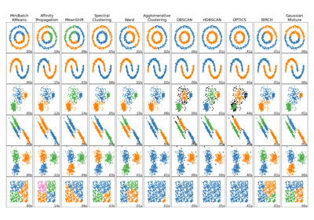

Comparing different clustering algorithms on toy datasets

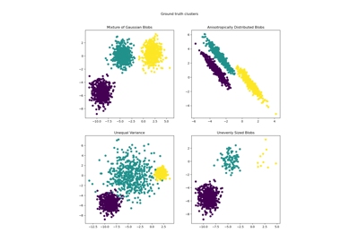

Demonstration of k-means assumptions

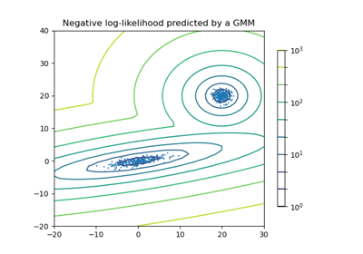

Density Estimation for a Gaussian mixture

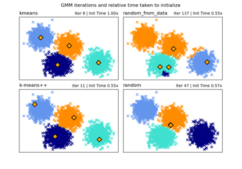

GMM Initialization Methods

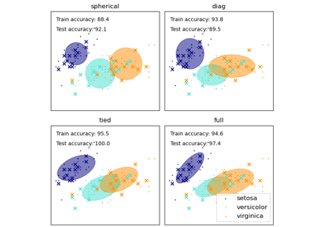

GMM covariances

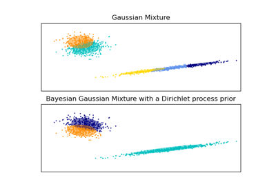

Gaussian Mixture Model Ellipsoids

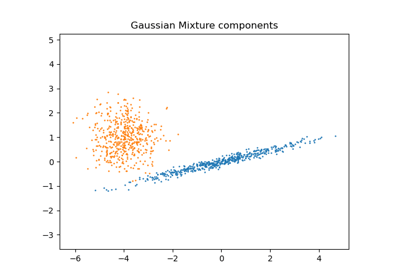

Gaussian Mixture Model Selection

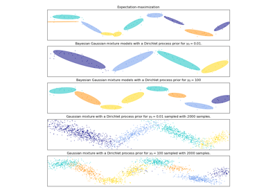

Gaussian Mixture Model Sine Curve

© 2007–2025 The scikit-learn developers  
Licensed under the 3-clause BSD License.  
https://scikit-learn.org/1.6/modules/generated/sklearn.mixture.GaussianMixture.html